# 红酒质量分析

```r
knitr::opts_chunk$set(message=FALSE,warn=FALSE,echo=FALSE)
```

### 本报告探究的数据集包含1,599 种红酒，以及 11 个关于酒的化学成分的变量及1个其质量评分。

# 单变量部分

```
## 'data.frame':    1599 obs. of  13 variables:
##  $ X                   : int  1 2 3 4 5 6 7 8 9 10 ...
##  $ fixed.acidity       : num  7.4 7.8 7.8 11.2 7.4 7.4 7.9 7.3 7.8 7.5 ...
##  $ volatile.acidity    : num  0.7 0.88 0.76 0.28 0.7 0.66 0.6 0.65 0.58 0.5 ...
##  $ citric.acid         : num  0 0 0.04 0.56 0 0 0.06 0 0.02 0.36 ...
##  $ residual.sugar      : num  1.9 2.6 2.3 1.9 1.9 1.8 1.6 1.2 2 6.1 ...
##  $ chlorides           : num  0.076 0.098 0.092 0.075 0.076 0.075 0.069 0.065 0.073 0.071 ...
##  $ free.sulfur.dioxide : num  11 25 15 17 11 13 15 15 9 17 ...
##  $ total.sulfur.dioxide: num  34 67 54 60 34 40 59 21 18 102 ...
##  $ density             : num  0.998 0.997 0.997 0.998 0.998 ...
##  $ pH                  : num  3.51 3.2 3.26 3.16 3.51 3.51 3.3 3.39 3.36 3.35 ...
##  $ sulphates           : num  0.56 0.68 0.65 0.58 0.56 0.56 0.46 0.47 0.57 0.8 ...
##  $ alcohol             : num  9.4 9.8 9.8 9.8 9.4 9.4 9.4 10 9.5 10.5 ...
##  $ quality             : int  5 5 5 6 5 5 5 7 7 5 ...
```

```
##        X          fixed.acidity   volatile.acidity  citric.acid
##  Min.   :   1.0   Min.   : 4.60   Min.   :0.1200   Min.   :0.000
##  1st Qu.: 400.5   1st Qu.: 7.10   1st Qu.:0.3900   1st Qu.:0.090
##  Median : 800.0   Median : 7.90   Median :0.5200   Median :0.260
##  Mean   : 800.0   Mean   : 8.32   Mean   :0.5278   Mean   :0.271
##  3rd Qu.:1199.5   3rd Qu.: 9.20   3rd Qu.:0.6400   3rd Qu.:0.420
##  Max.   :1599.0   Max.   :15.90   Max.   :1.5800   Max.   :1.000
##  residual.sugar     chlorides       free.sulfur.dioxide
##  Min.   : 0.900   Min.   :0.01200   Min.   : 1.00
##  1st Qu.: 1.900   1st Qu.:0.07000   1st Qu.: 7.00
##  Median : 2.200   Median :0.07900   Median :14.00
##  Mean   : 2.539   Mean   :0.08747   Mean   :15.87
##  3rd Qu.: 2.600   3rd Qu.:0.09000   3rd Qu.:21.00
##  Max.   :15.500   Max.   :0.61100   Max.   :72.00
##  total.sulfur.dioxide    density             pH          sulphates
##  Min.   :  6.00       Min.   :0.9901   Min.   :2.740   Min.   :0.3300
##  1st Qu.: 22.00       1st Qu.:0.9956   1st Qu.:3.210   1st Qu.:0.5500
##  Median : 38.00       Median :0.9968   Median :3.310   Median :0.6200
##  Mean   : 46.47       Mean   :0.9967   Mean   :3.311   Mean   :0.6581
##  3rd Qu.: 62.00       3rd Qu.:0.9978   3rd Qu.:3.400   3rd Qu.:0.7300
##  Max.   :289.00       Max.   :1.0037   Max.   :4.010   Max.   :2.0000
##     alcohol         quality
##  Min.   : 8.40   Min.   :3.000
##  1st Qu.: 9.50   1st Qu.:5.000
##  Median :10.20   Median :6.000
##  Mean   :10.42   Mean   :5.636
##  3rd Qu.:11.10   3rd Qu.:6.000
##  Max.   :14.90   Max.   :8.000
```

#### 我们这个数据集有13个变量，1599行数据组成。

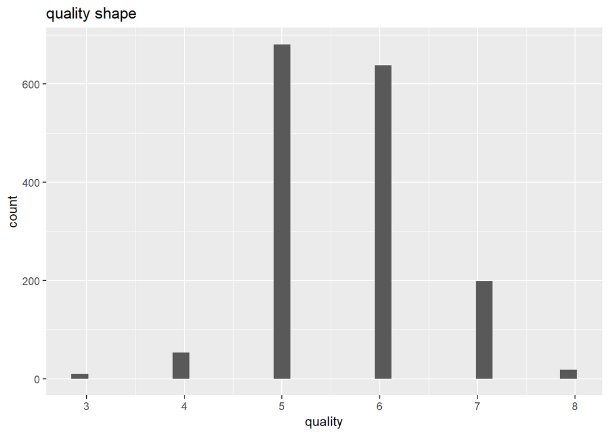

#### 数据集中红酒的质量评分大多在5~7之间。

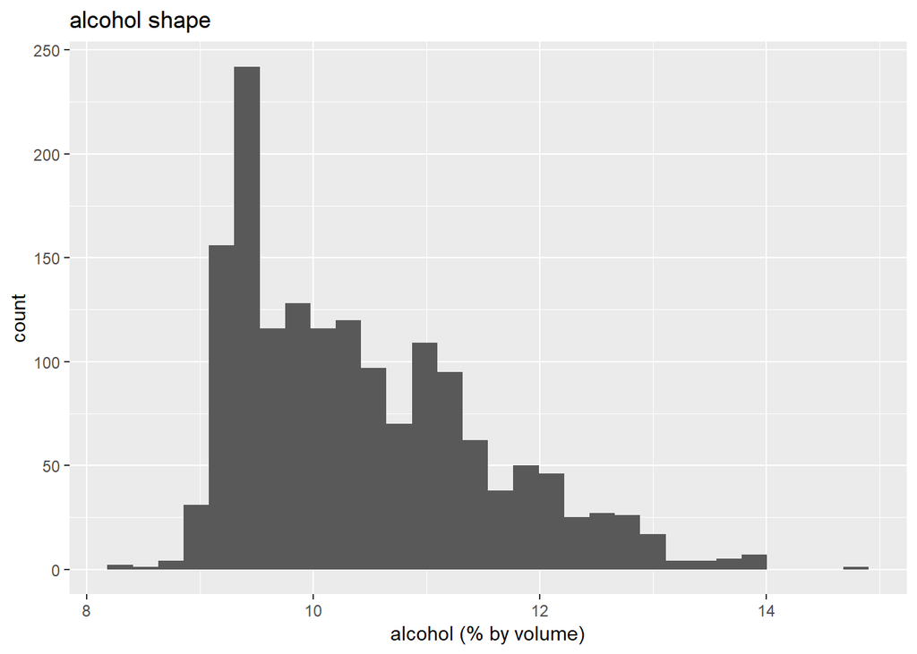

```
##    Min. 1st Qu.  Median    Mean 3rd Qu.    Max.
##    8.40    9.50   10.20   10.42   11.10   14.90
```

```
##
##              8.4              8.5              8.7              8.8
##                2                1                2                2
##                9             9.05              9.1              9.2
##               30                1               23               72
## 9.23333333333333             9.25              9.3              9.4
##                1                1               59              103
##              9.5             9.55 9.56666666666667              9.6
##              139                2                1               59
##              9.7              9.8              9.9             9.95
##               54               78               49                1
##               10 10.0333333333333             10.1             10.2
##               67                2               47               46
##             10.3             10.4             10.5            10.55
##               33               41               67                2
##             10.6             10.7            10.75             10.8
##               28               27                1               42
##             10.9               11 11.0666666666667             11.1
##               49               59                1               27
##             11.2             11.3             11.4             11.5
##               36               32               32               30
##             11.6             11.7             11.8             11.9
##               15               23               29               20
##            11.95               12             12.1             12.2
##                1               21               13               12
##             12.3             12.4             12.5             12.6
##               12               13               21                6
##             12.7             12.8             12.9               13
##                9               17                9                6
##             13.1             13.2             13.3             13.4
##                2                1                3                3
##             13.5 13.5666666666667             13.6               14
##                1                1                4                7
##             14.9
##                1
```

#### 数据集中酒精浓度主要介于9到13之间，但是在9~13之间有少数酒精浓度的数量很少。

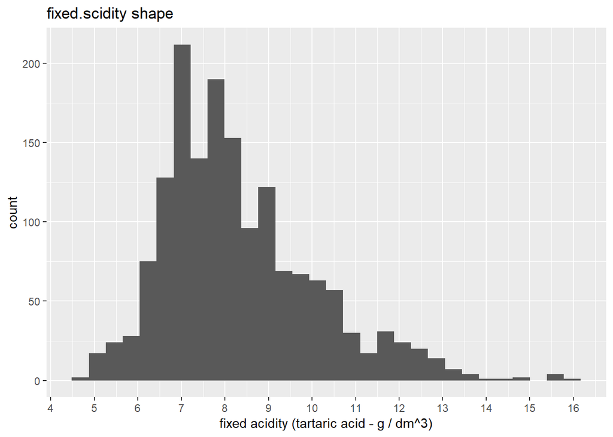

#### 数据集中fixd.acidity的浓度大多介于6~10.

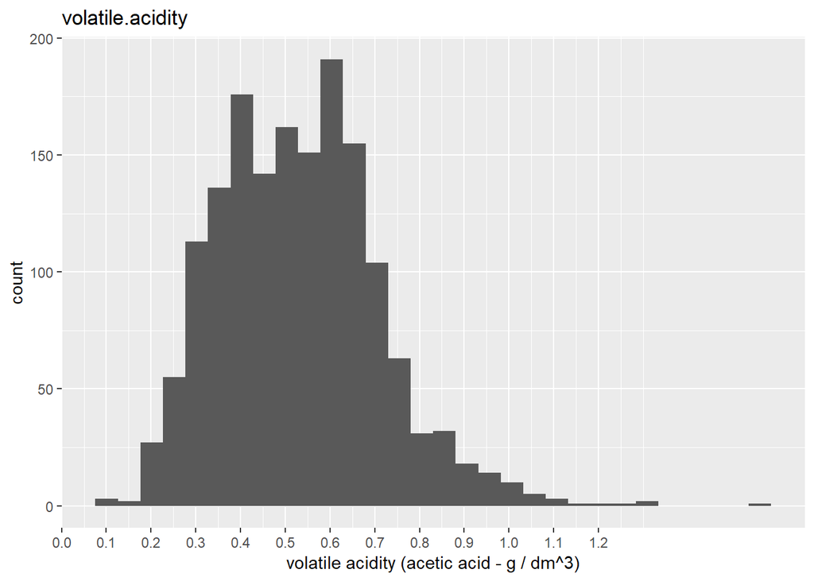

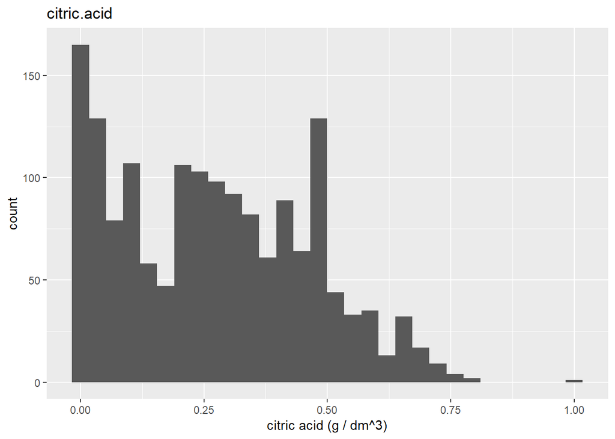

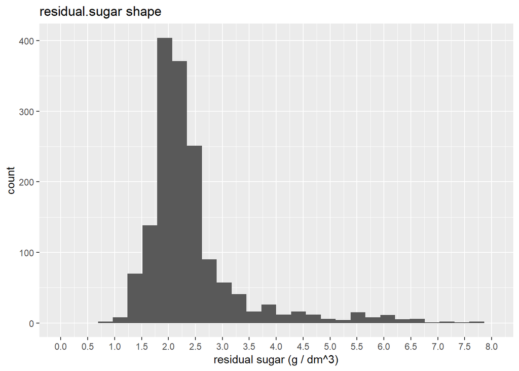

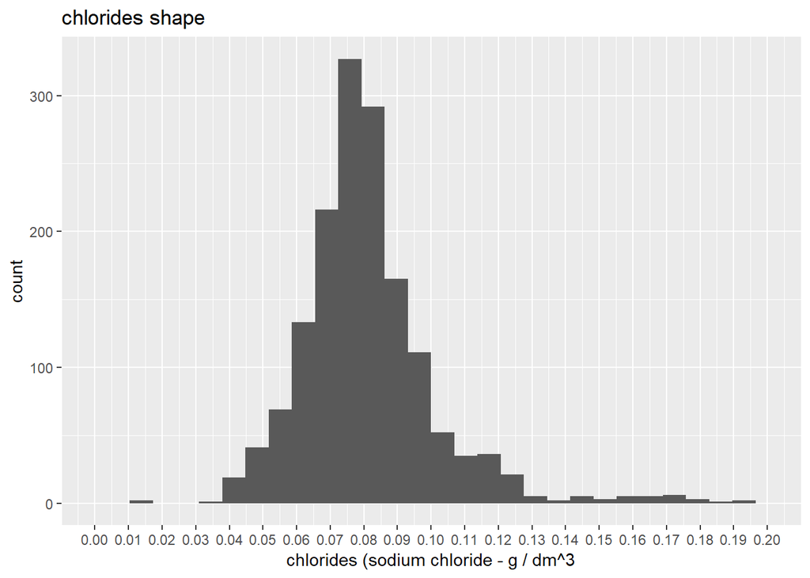

#### 氯化物浓度主要在0.04到0.12之间。

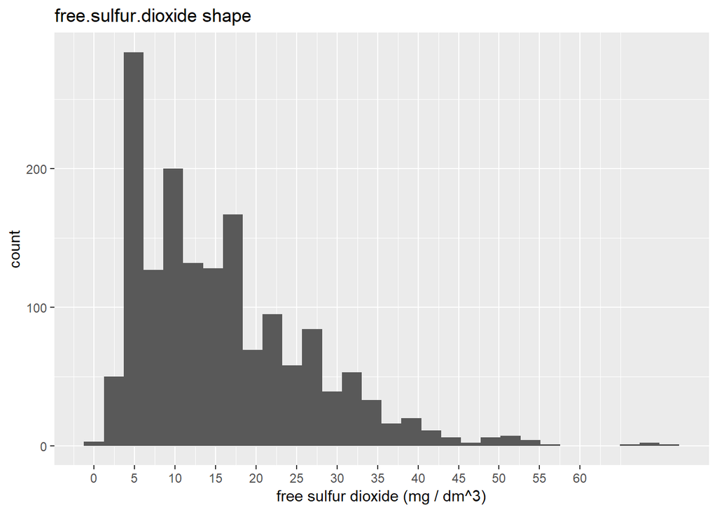

#### 游离二氧化硫浓度主要在5~35之间。

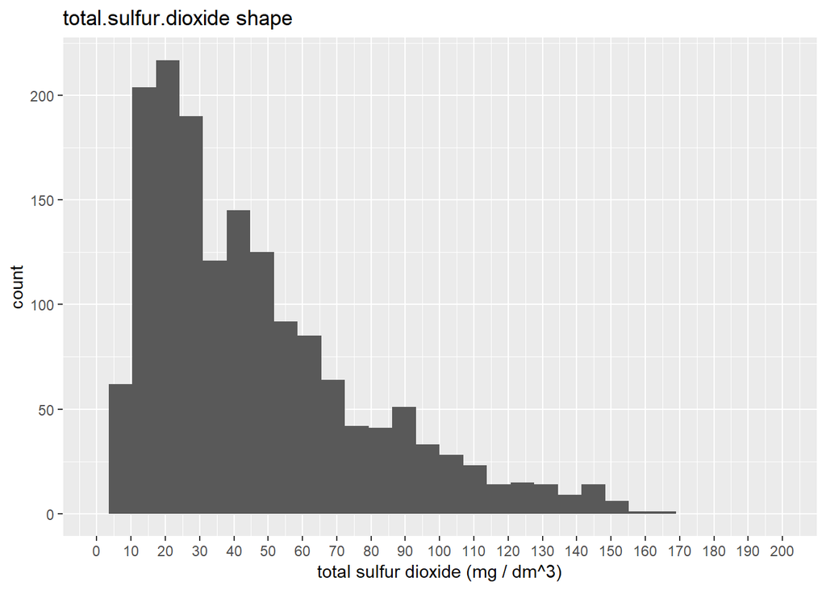

#### 数据集中总的二氧化硫浓度主要在10~100之间。

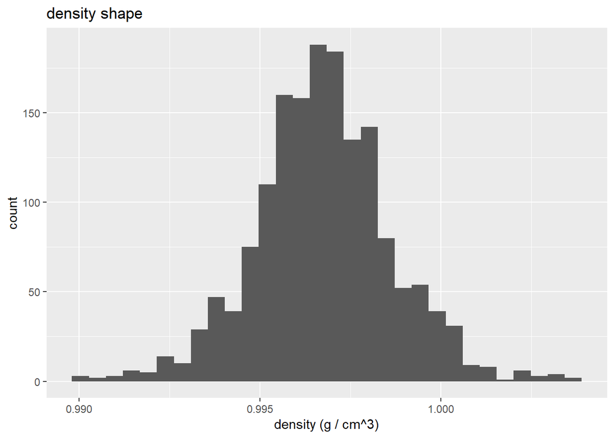

#### 数据集中的红酒密度大多在0.995~1.000间，这其中只有几种密度是数量最多的。

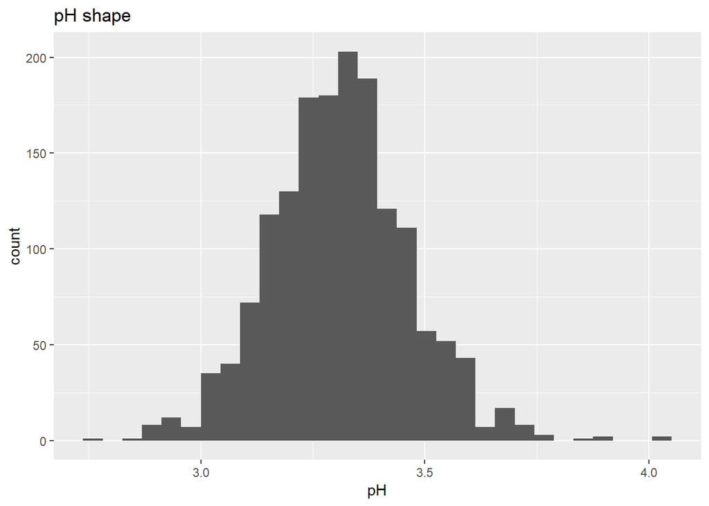

#### 数据集中红酒pH值大多介于3~3.5之间。

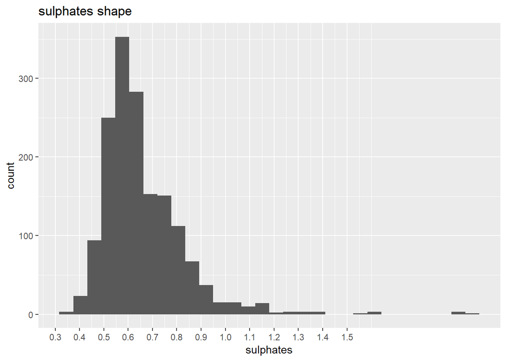

#### 数据集中硫酸盐浓度在0.4~1.0之间。

## 单变量分析

### What is the structure of your dataset?

低——>高 质量：0(非常差) —— 10(非常好)

### What is/are the main feature(s) of interest in your dataset?

#### 主要功能是红酒质量与化学成分的关系。探究哪些化学成分影响这酒的质量高低。

### What other features in the dataset do you think will help support your investigation into your feature(s) of interest?

在红酒密度的直方图中，个别几种的密度情况却占据了大多数数量，离散程度大。

# 探索双变量部分

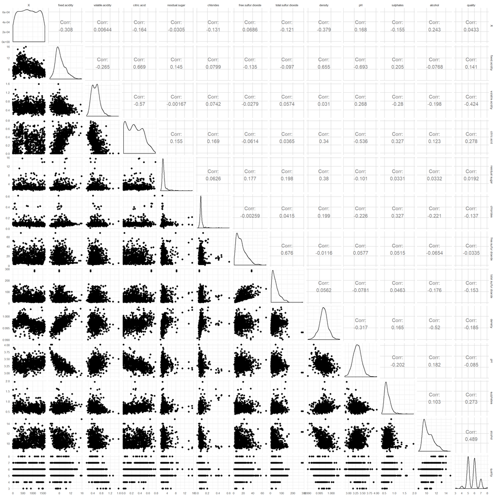

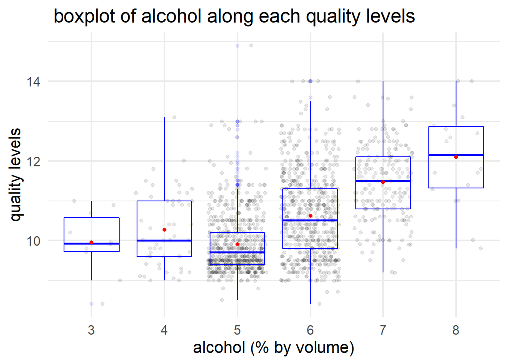

#### 质量主要在5，6，7三种中。酒精浓度主要在9~13之间。在一定范围内，酒精浓度增加，酒的质量也在增加。

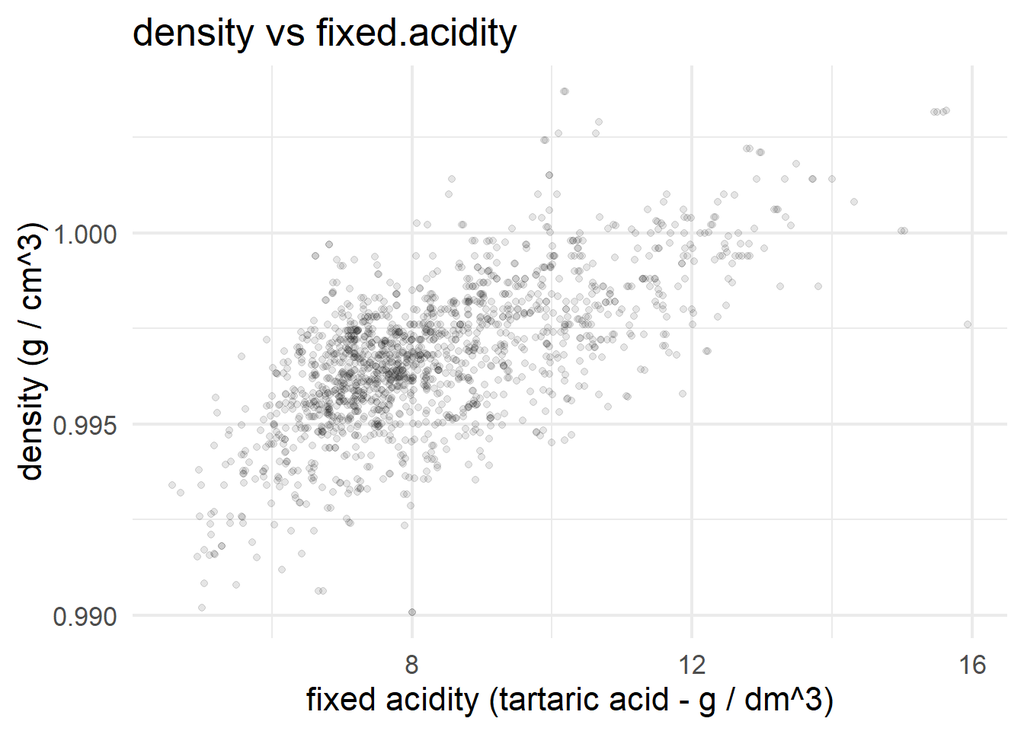

```
##
##  Pearson's product-moment correlation
##
## data:  fixed.acidity and density
## t = 35.877, df = 1597, p-value < 2.2e-16
## alternative hypothesis: true correlation is not equal to 0
## 95 percent confidence interval:
##  0.6399847 0.6943302
## sample estimates:
##       cor
## 0.6680473
```

#### 固定酸度与密度呈线性关系，固定酸度浓度增加，密度也增加。红酒密度大部分在0.995至1.00之间。

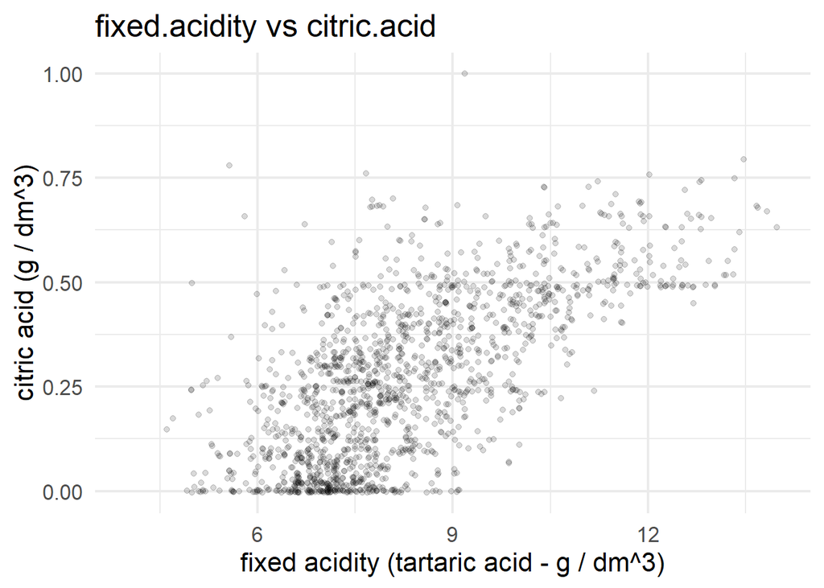

```
##
##  Pearson's product-moment correlation
##
## data:  fixed.acidity and citric.acid
## t = 36.234, df = 1597, p-value < 2.2e-16
## alternative hypothesis: true correlation is not equal to 0
## 95 percent confidence interval:
##  0.6438839 0.6977493
## sample estimates:
##       cor
## 0.6717034
```

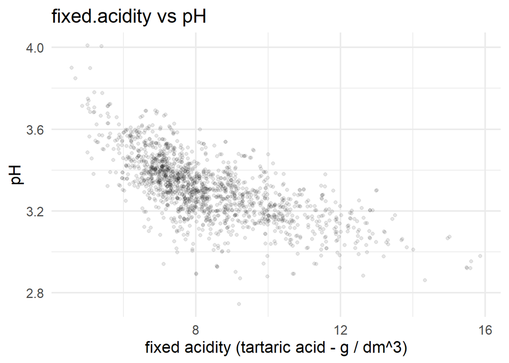

```
##
##  Pearson's product-moment correlation
##
## data:  fixed.acidity and pH
## t = -37.366, df = 1597, p-value < 2.2e-16
## alternative hypothesis: true correlation is not equal to 0
## 95 percent confidence interval:
##  -0.7082857 -0.6559174
## sample estimates:
##        cor
## -0.6829782
```

#### 在质量为5~7的红酒中，随着固定酸度浓度的增加，红酒的pH值在减小，两者呈负相关。

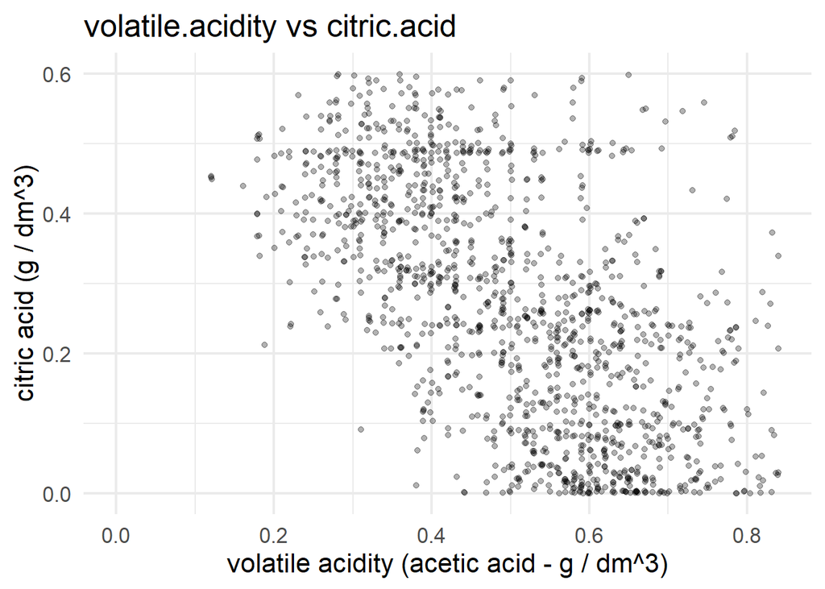

```
##
##  Pearson's product-moment correlation
##
## data:  volatile.acidity and citric.acid
## t = -26.489, df = 1597, p-value < 2.2e-16
## alternative hypothesis: true correlation is not equal to 0
## 95 percent confidence interval:
##  -0.5856550 -0.5174902
## sample estimates:
##        cor
## -0.5524957
```

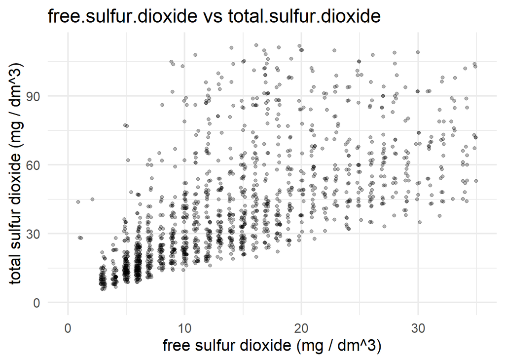

```
##
##  Pearson's product-moment correlation
##
## data:  free.sulfur.dioxide and total.sulfur.dioxide
## t = 35.84, df = 1597, p-value < 2.2e-16
## alternative hypothesis: true correlation is not equal to 0
## 95 percent confidence interval:
##  0.6395786 0.6939740
## sample estimates:
##       cor
## 0.6676665
```

#### 在游离二氧化硫浓度在2.5~25之间，游离二氧化硫与总体二氧化硫呈很强的线性关系，但有垂直带，相同游离二氧化硫浓度下，总体二氧化硫有很多值。

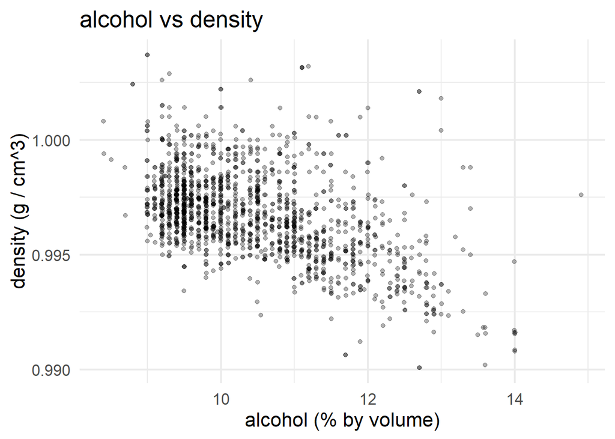

```
##
##  Pearson's product-moment correlation
##
## data:  alcohol and density
## t = -22.838, df = 1597, p-value < 2.2e-16
## alternative hypothesis: true correlation is not equal to 0
## 95 percent confidence interval:
##  -0.5322547 -0.4583061
## sample estimates:
##        cor
## -0.4961798
```

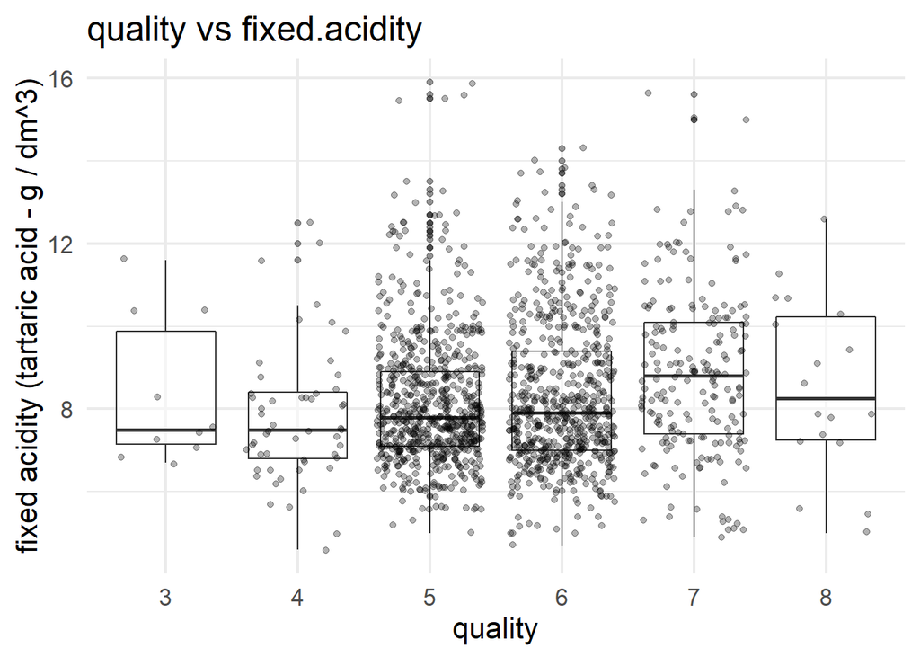

```
## df$quality: 3
##    Min. 1st Qu.  Median    Mean 3rd Qu.    Max.
##   6.700   7.150   7.500   8.360   9.875  11.600
## --------------------------------------------------------
## df$quality: 4
##    Min. 1st Qu.  Median    Mean 3rd Qu.    Max.
##   4.600   6.800   7.500   7.779   8.400  12.500
## --------------------------------------------------------
## df$quality: 5
##    Min. 1st Qu.  Median    Mean 3rd Qu.    Max.
##   5.000   7.100   7.800   8.167   8.900  15.900
## --------------------------------------------------------
## df$quality: 6
##    Min. 1st Qu.  Median    Mean 3rd Qu.    Max.
##   4.700   7.000   7.900   8.347   9.400  14.300
## --------------------------------------------------------
## df$quality: 7
##    Min. 1st Qu.  Median    Mean 3rd Qu.    Max.
##   4.900   7.400   8.800   8.872  10.100  15.600
## --------------------------------------------------------
## df$quality: 8
##    Min. 1st Qu.  Median    Mean 3rd Qu.    Max.
##   5.000   7.250   8.250   8.567  10.225  12.600
```

#### 各种质量下，quality为5，6，7的三种质量数据最多，Median值在7.8到8.8之间。

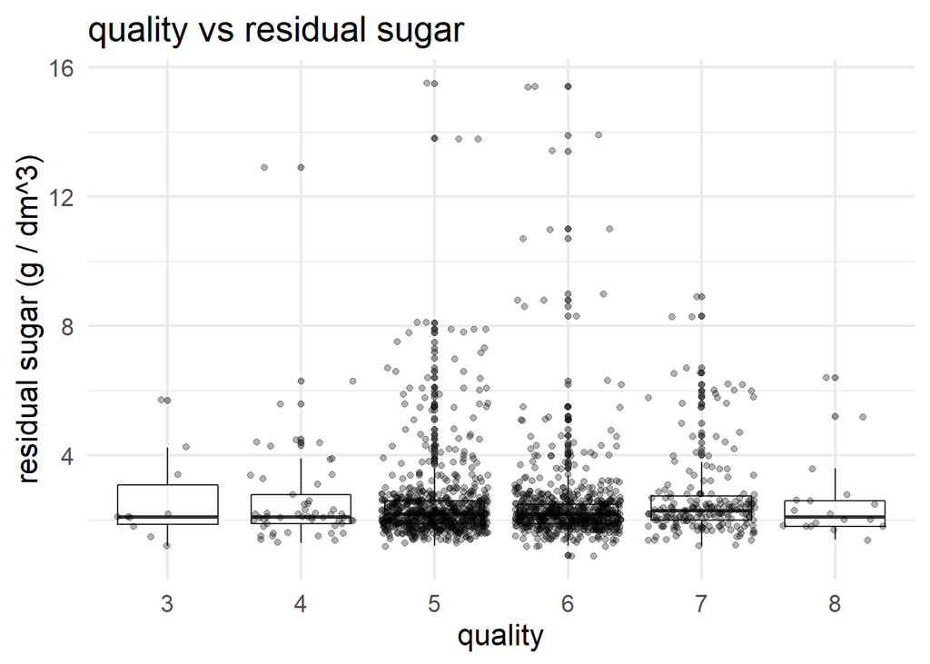

```
## df$quality: 3
##    Min. 1st Qu.  Median    Mean 3rd Qu.    Max.
##   1.200   1.875   2.100   2.635   3.100   5.700
## --------------------------------------------------------
## df$quality: 4
##    Min. 1st Qu.  Median    Mean 3rd Qu.    Max.
##   1.300   1.900   2.100   2.694   2.800  12.900
## --------------------------------------------------------
## df$quality: 5
##    Min. 1st Qu.  Median    Mean 3rd Qu.    Max.
##   1.200   1.900   2.200   2.529   2.600  15.500
## --------------------------------------------------------
## df$quality: 6
##    Min. 1st Qu.  Median    Mean 3rd Qu.    Max.
##   0.900   1.900   2.200   2.477   2.500  15.400
## --------------------------------------------------------
## df$quality: 7
##    Min. 1st Qu.  Median    Mean 3rd Qu.    Max.
##   1.200   2.000   2.300   2.721   2.750   8.900
## --------------------------------------------------------
## df$quality: 8
##    Min. 1st Qu.  Median    Mean 3rd Qu.    Max.
##   1.400   1.800   2.100   2.578   2.600   6.400
```

#### 在各种质量下，查看残留糖的各种统计量，数据主要集中在5，6，7三种质量上。

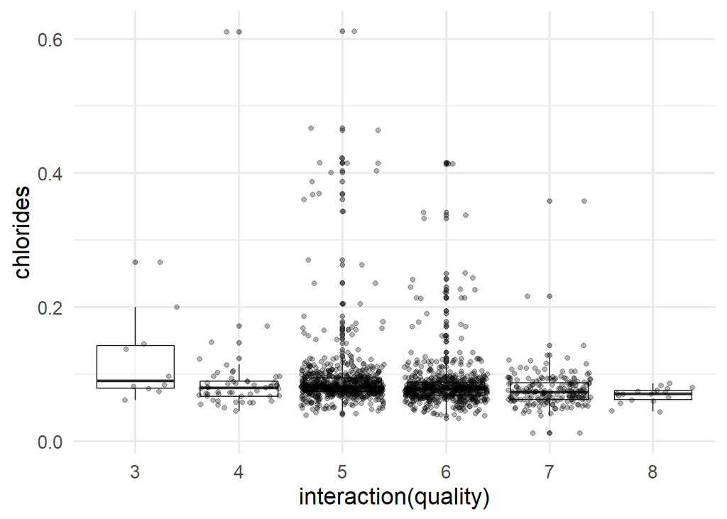

```
## df$quality: 3
##    Min. 1st Qu.  Median    Mean 3rd Qu.    Max.
##  0.0610  0.0790  0.0905  0.1225  0.1430  0.2670
## --------------------------------------------------------
## df$quality: 4
##    Min. 1st Qu.  Median    Mean 3rd Qu.    Max.
## 0.04500 0.06700 0.08000 0.09068 0.08900 0.61000
## --------------------------------------------------------
## df$quality: 5
##    Min. 1st Qu.  Median    Mean 3rd Qu.    Max.
## 0.03900 0.07400 0.08100 0.09274 0.09400 0.61100
## --------------------------------------------------------
## df$quality: 6
##    Min. 1st Qu.  Median    Mean 3rd Qu.    Max.
## 0.03400 0.06825 0.07800 0.08496 0.08800 0.41500
## --------------------------------------------------------
## df$quality: 7
##    Min. 1st Qu.  Median    Mean 3rd Qu.    Max.
## 0.01200 0.06200 0.07300 0.07659 0.08700 0.35800
## --------------------------------------------------------
## df$quality: 8
##    Min. 1st Qu.  Median    Mean 3rd Qu.    Max.
## 0.04400 0.06200 0.07050 0.06844 0.07550 0.08600
```

#### 在各种质量下，查看氯化物的各种值。Median的主要范围在0.0730到0.0810间。

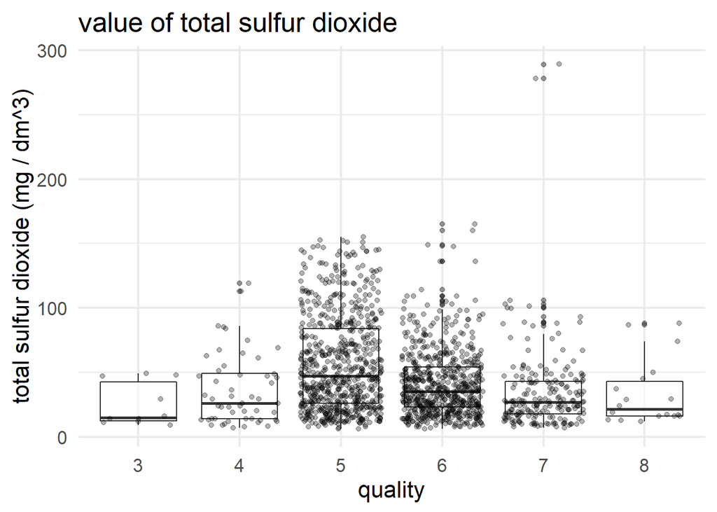

```
## df$quality: 3
##    Min. 1st Qu.  Median    Mean 3rd Qu.    Max.
##     9.0    12.5    15.0    24.9    42.5    49.0
## --------------------------------------------------------
## df$quality: 4
##    Min. 1st Qu.  Median    Mean 3rd Qu.    Max.
##    7.00   14.00   26.00   36.25   49.00  119.00
## --------------------------------------------------------
## df$quality: 5
##    Min. 1st Qu.  Median    Mean 3rd Qu.    Max.
##    6.00   26.00   47.00   56.51   84.00  155.00
## --------------------------------------------------------
## df$quality: 6
##    Min. 1st Qu.  Median    Mean 3rd Qu.    Max.
##    6.00   23.00   35.00   40.87   54.00  165.00
## --------------------------------------------------------
## df$quality: 7
##    Min. 1st Qu.  Median    Mean 3rd Qu.    Max.
##    7.00   17.50   27.00   35.02   43.00  289.00
## --------------------------------------------------------
## df$quality: 8
##    Min. 1st Qu.  Median    Mean 3rd Qu.    Max.
##   12.00   16.00   21.50   33.44   43.00   88.00
```

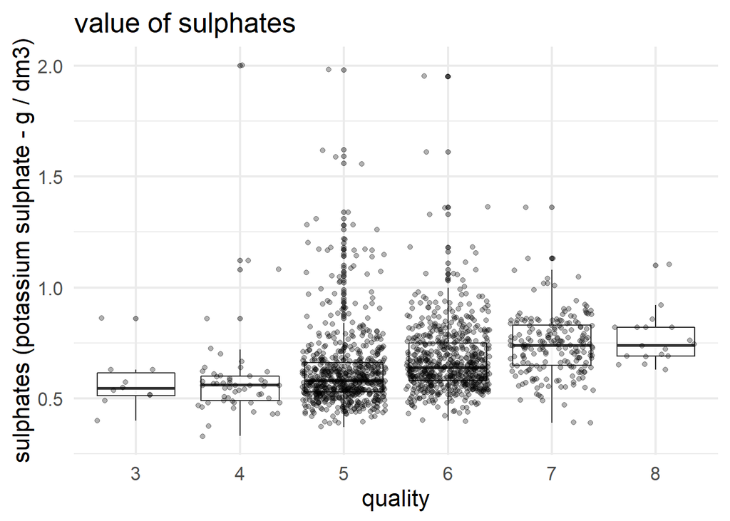

```
## df$quality: 3
##    Min. 1st Qu.  Median    Mean 3rd Qu.    Max.
##  0.4000  0.5125  0.5450  0.5700  0.6150  0.8600
## --------------------------------------------------------
## df$quality: 4
##    Min. 1st Qu.  Median    Mean 3rd Qu.    Max.
##  0.3300  0.4900  0.5600  0.5964  0.6000  2.0000
## --------------------------------------------------------
## df$quality: 5
##    Min. 1st Qu.  Median    Mean 3rd Qu.    Max.
##   0.370   0.530   0.580   0.621   0.660   1.980
## --------------------------------------------------------
## df$quality: 6
##    Min. 1st Qu.  Median    Mean 3rd Qu.    Max.
##  0.4000  0.5800  0.6400  0.6753  0.7500  1.9500
## --------------------------------------------------------
## df$quality: 7
##    Min. 1st Qu.  Median    Mean 3rd Qu.    Max.
##  0.3900  0.6500  0.7400  0.7413  0.8300  1.3600
## --------------------------------------------------------
## df$quality: 8
##    Min. 1st Qu.  Median    Mean 3rd Qu.    Max.
##  0.6300  0.6900  0.7400  0.7678  0.8200  1.1000
```

#### 在各种质量下，查看硫酸盐的的各种值，Median主要范围在0.58到0.74间。

## 双变量分析

### Did you observe any interesting relationships between the other features (not the main feature(s) of interest)?

# 多变量部分

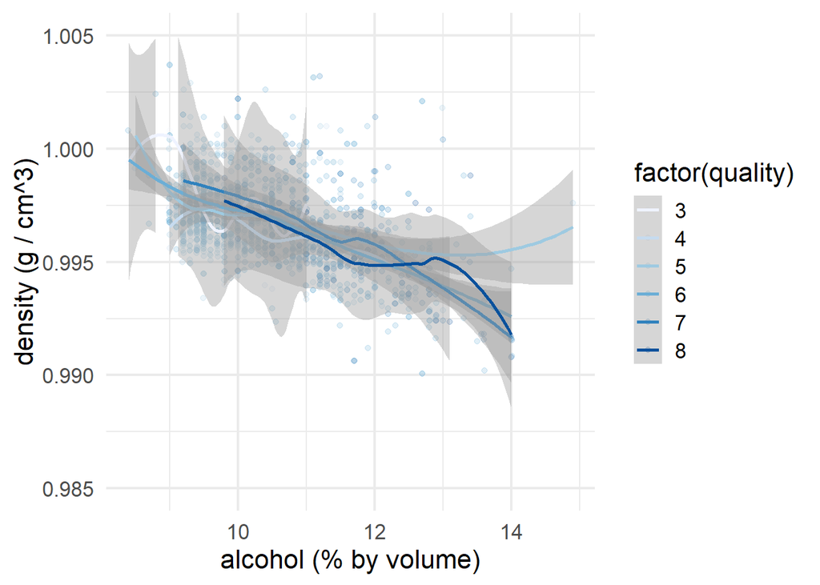

```
## $title
## [1] "density vs alcohol vs quality"
##
## $subtitle
## NULL
##
## attr(,"class")
## [1] "labels"
```

#### 在各种的质量情况下，随着酒精浓度的增加，密度亦随之减小。大体上是呈负相关性。

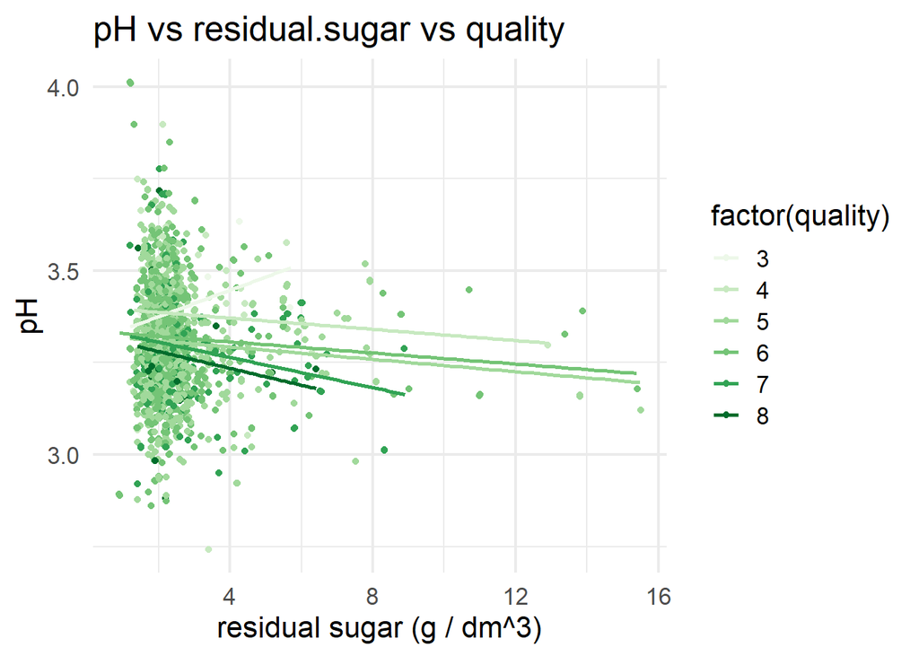

#### 在各种质量下，pH值随残留糖变化的情况。在质量为3的情况下，residual.sugar与pH呈正相关，其他质量下都呈负相关性。

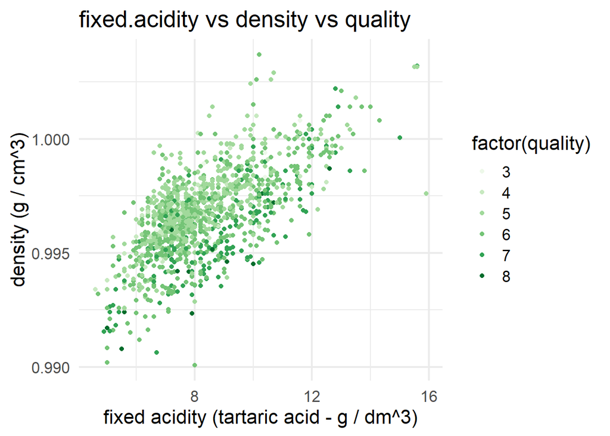

#### 图中是固定酸度与密度在各种质量下的关系，当固定酸度上确定一点时，质量越高其密度越低。总体上看，固定酸度与密度是正相关的。

# 多变量分析

### Talk about some of the relationships you observed in this part of the investigation. Were there features that strengthened each other in terms of looking at your feature(s) of interest?

在这部分我主要查看了高质量的红酒的各种化学元素浓度值范围，来帮助大家更好的来预测红酒是否能被评为高质量红酒。

### Were there any interesting or surprising interactions between features?

在质量为5，6,7的情况下，随着酒精浓度的增加，密度亦随之减小，但是质量为5时，密度有上升趋势。

### OPTIONAL: Did you create any models with your dataset? Discuss the strengths and limitations of your model.

# 最后总结

### 图一

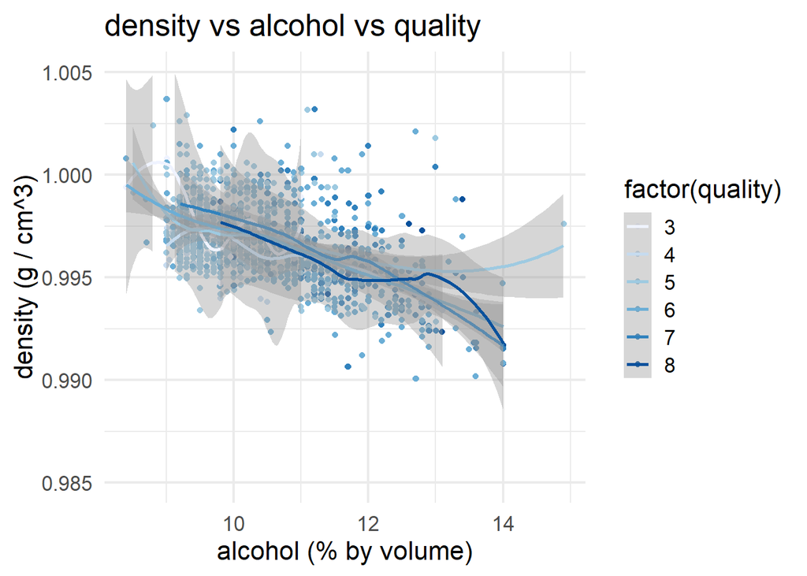

### 描述：

按理说，quality=5时，其密度应该岁酒精增加而减小，可是当超过alcohol大于13时，反而上升。

### 图二

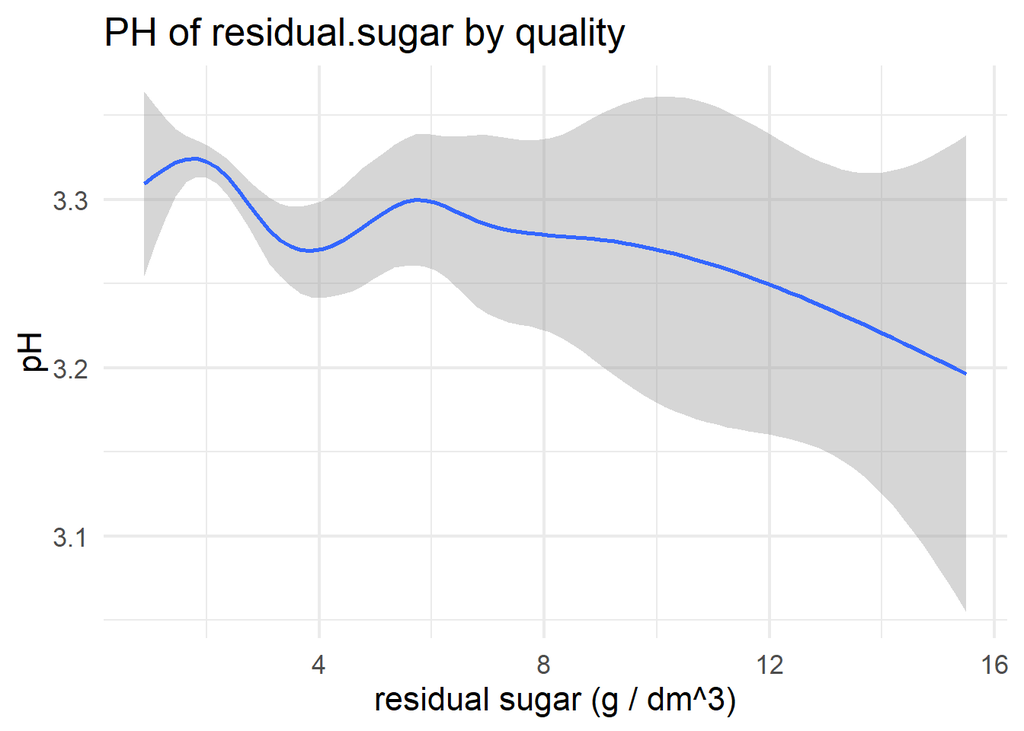

### 图三

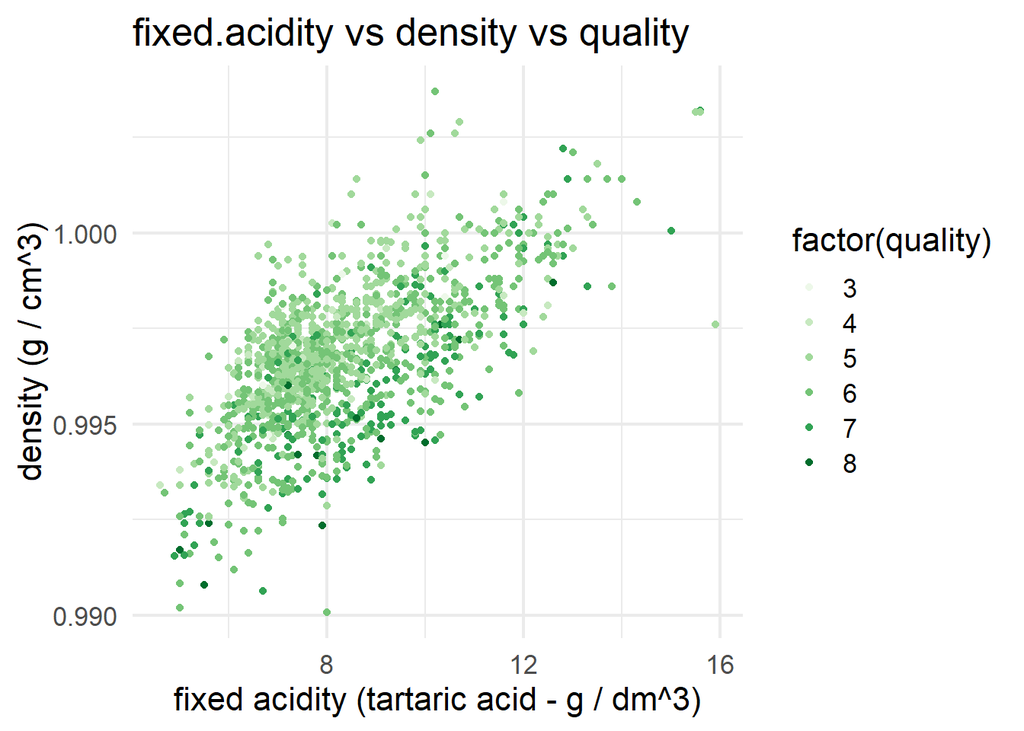

### 描述：

保持固定酸度浓度恒定，具有更高质量的红酒总体上比较低质量的红酒的密度更低。

# 反思：

在分析过程中，不知道到底哪些变量影响着红酒的品质，只能用ggpairs函数，把所有变量关系都列出来，找到相关系数偏大的变量。 对此数据集，以后还可以用来预测红酒的质量，但前提是数据集数据合适，且处理完善，预测方法准确，这样就能自动检测红酒品质了。